# Módulo (electivo) — Growth-at-Risk: la distribución del PIB, no solo su media, y la humildad del dato en tiempo real

**Curso complementario · puremacro**

### Objetivos de aprendizaje

Al terminar esta lección podrás:

1. **Confrontar** el modelo estándar de agente representativo —que reduce el pronóstico a una **media** con varianza constante y simétrica— con un hecho que no explica: la **distribución condicional** del crecimiento del PIB es **asimétrica y variable**.
2. Estimar **Growth-at-Risk** con `puremacro.gar`: una **autorregresión cuantílica** (`qar`) del crecimiento del PIB con las **condiciones financieras** como control.
3. Ajustar una **skew-t** a los cuantiles predichos (`fit_skewt_to_quantiles`, `skewt_pdf`) y leer la **densidad condicional**: la cola izquierda **engorda** cuando aprietan las condiciones financieras (Adrian, Boyarchenko y Giannone, 2019).
4. Interiorizar la **humildad del dato en tiempo real** (Orphanides): el riesgo se evalúa hoy con el dato equivocado — el PIB de 2008Q4 se vio **−3.8 %** y hoy es **−8.5 %**.

Todo corre en Python puro sobre tu **instalación local** de `puremacro` (`pip install puremacro`), leyendo datos locales del bundle: sin conexión y sin costo.

## 1. La confrontación: la media no es el riesgo

El modelo neoclásico/RBC con **agente representativo** escribe el producto como una tendencia más un choque:

$$\log y_{t+1} = \mu_t + \varepsilon_{t+1}, \qquad \varepsilon_{t+1}\sim\mathcal{N}(0,\sigma^2).$$

Con innovaciones **gaussianas** y varianza **constante**, la densidad predictiva es **simétrica** y su forma no cambia con el estado de la economía: el **pronóstico puntual** $\mu_t$ (la media) es un estadístico suficiente. Bajo esa vista, "riesgo a la baja" y "riesgo al alza" son lo mismo.

**El hecho que no explica** (Adrian, Boyarchenko y Giannone, 2019, *Vulnerable Growth*): la distribución condicional del crecimiento del PIB **no es simétrica ni fija**. Cuando las **condiciones financieras se aprietan**, la **cola izquierda se engorda** —el escenario malo empeora mucho— mientras la **cola derecha casi no se mueve**. El centro de la distribución se desplaza, sí, pero **mucho menos que la cola**: abajo estimaremos que un barrido completo de la NFCI hunde el cuantil 5 % unos **10 puntos** y la mediana solo **2.5**. El **riesgo a la baja** se dispara sin que el pronóstico puntual dé la alarma en la misma medida: el resumen por la media pierde justo lo que le importa a la política.

## 2. Growth-at-Risk con `puremacro.gar`

**Ingredientes** (Python puro):

- `A191RL1Q225SBEA.csv` — crecimiento del PIB real de EE. UU., trimestral **anualizado (%)**.
- `NFCI.csv` — índice de condiciones financieras nacionales de la Fed de Chicago (semanal; **más alto = más apretado**), que agregamos a trimestral.

**Ficha de medición** (el curso no publica un momento condicional sin ella):

| campo | valor |
| --- | --- |
| fuente/serie | FRED `A191RL1Q225SBEA` (PIB real, tasa trimestral **anualizada**, %) y FRED `NFCI` |
| muestra de estimación | **1971Q1–2019Q4** (n = 196); el PIB arranca en 1947 y la NFCI en 1971 — hay que **alinear antes de regresar** |
| agregación de la NFCI | semanal → media trimestral (`resample("QS")`), fechada al inicio del trimestre |
| especificación | QAR con p = 4 rezagos de $g$, NFCI$_t$ como control, horizonte h = 1 |
| corte muestral | **excluye 2020 en adelante**: 2020Q2 (−28 %) y 2020Q3 (+35 %) son dos observaciones que, en una regresión cuantílica, *dominan* las colas (§2.3 lo muestra) |
| edición/vintage | serie **revisada** de hoy (CSV congelado del bundle); §3 la confronta con las primeras publicaciones |

**Receta ABG-2019** en dos pasos, ambos en `puremacro.gar`:

1. `qar` — autorregresión cuantílica: para cada cuantil $\tau$ estima $Q_\tau[g_{t+1}\mid g_t,\dots,g_{t-3},\ \text{NFCI}_t]=\alpha_\tau+\sum_l\beta_{\tau,l}\,g_{t-l}+\gamma_\tau\,\text{NFCI}_t$.
2. `fit_skewt_to_quantiles` — ajusta una **skew-t** de Azzalini $(\mu,\sigma,\alpha,\nu)$ a los cuantiles predichos; `skewt_pdf` da la **densidad condicional** suave.

```python
from puremacro.gar import qar, fit_skewt_to_quantiles, skewt_pdf

# Crecimiento del PIB (anualizado, %), trimestral.
g = (pd.read_csv(DATA / "A191RL1Q225SBEA.csv", parse_dates=["observation_date"])
       .rename(columns={"A191RL1Q225SBEA": "gdp"})
       .set_index("observation_date")["gdp"])

# NFCI semanal -> media trimestral (inicio de trimestre, alineado con el PIB).
nfci_q = (pd.read_csv(DATA / "NFCI.csv", parse_dates=["observation_date"])
            .set_index("observation_date")["NFCI"]
            .resample("QS").mean())

# Alinear PRIMERO (el PIB arranca en 1947; la NFCI en 1971): `qar` apila por
# posición, así que sin esta intersección el control iría desfasado 24 años.
panel_full = pd.concat([g, nfci_q.rename("nfci")], axis=1).dropna()
panel = panel_full.loc[:"2019-10-01"]        # corte pre-COVID (ver ficha)
def _qlabel(ts):
    return f"{ts.year}Q{(ts.month - 1) // 3 + 1}"
print(f"Datos alineados:      {_qlabel(panel_full.index.min())}"
      f" -> {_qlabel(panel_full.index.max())}  (n = {len(panel_full)})")
print(f"Muestra de estimación: {_qlabel(panel.index.min())}"
      f" -> {_qlabel(panel.index.max())}  (n = {len(panel)})")
print(f"NFCI  2005Q2 (tranquilo) = {panel.loc['2005-04-01','nfci']:+.2f}   "
      f"2008Q4 (crisis) = {panel.loc['2008-10-01','nfci']:+.2f}")
```

```
Datos alineados:      1971Q1 -> 2026Q1  (n = 221)
Muestra de estimación: 1971Q1 -> 2019Q4  (n = 196)
NFCI  2005Q2 (tranquilo) = -0.61   2008Q4 (crisis) = +2.77
```

### El motor: `qar` con NFCI como control

Estimamos los cuantiles de $g_{t+1}$ (horizonte $h=1$) con 4 rezagos y la NFCI como control. La firma `qar(...)` devuelve, por cada $(h,\tau)$, los coeficientes `beta0…beta5` (intercepto, 4 rezagos, y el coeficiente de la NFCI en `beta5`).

**Convención de fechado** (importante para reconstruir a mano el predictor): el bloque autorregresivo de `qar` empieza en el valor **contemporáneo**, así que `beta1`$=g_t$, `beta2`$=g_{t-1}$, `beta3`$=g_{t-2}$, `beta4`$=g_{t-3}$ y `beta5`$=$NFCI$_t$.

```python
taus = (0.05, 0.10, 0.25, 0.50, 0.75, 0.90, 0.95)
fit = qar(panel["gdp"].values, quantiles=taus, horizons=(1,), p=4,
          controls=panel["nfci"].values, n_boot=100, seed=1)
Q = fit[fit["h"] == 1].set_index("tau")
betacols = ["beta0", "beta1", "beta2", "beta3", "beta4", "beta5"]

# El corazón del hecho ABG: el coeficiente de la NFCI (beta5) por cuantil.
print("  tau   coef. NFCI (beta5)")
for t in taus:
    print(f"  {t:.2f}      {Q.loc[t, 'beta5']:+.2f}")
gamma_lo, gamma_hi = Q.loc[0.05, "beta5"], Q.loc[0.95, "beta5"]
print(f"\nApretar condiciones golpea la cola IZQUIERDA (tau=.05: {gamma_lo:+.2f}) "
      f"mucho más que la derecha (tau=.95: {gamma_hi:+.2f}).")
assert gamma_lo < gamma_hi                    # la asimetría de ABG (2019)
assert abs(gamma_lo) > 5 * abs(gamma_hi)      # y es una asimetría GRANDE
```

```
  tau   coef. NFCI (beta5)
  0.05      -2.34
  0.10      -1.93
  0.25      -1.60
  0.50      -0.61
  0.75      -0.26
  0.90      +0.14
  0.95      +0.20

Apretar condiciones golpea la cola IZQUIERDA (tau=.05: -2.34) mucho más que la derecha (tau=.95: +0.20).
```

### 2.3 Por qué la muestra se corta en 2019Q4 (y por qué hay que decirlo)

Una regresión **cuantílica** de cola estima con muy pocos puntos: el 5 % de 196 trimestres son ~10 observaciones. Meter 2020 basta para desfigurarlas: en 2020Q2 el PIB cae **−28 %** con la NFCI en −0.08 —su lectura más alta desde 2012, por encima del 64 % de la muestra 1971–2019— y al trimestre siguiente **rebota +35 %**. Esa pareja (condiciones relativamente apretadas hoy, crecimiento enorme mañana) es exactamente lo contrario del hecho de ABG, y con dos observaciones de tanta palanca **cuadruplica** el coeficiente de la NFCI en el cuantil 95 %: apretar condiciones parecería *subir* la cola buena. No es un hecho económico; es el cierre y la reapertura de la economía. Lo mostramos en vez de esconderlo: la elección de muestra **es** un resultado que hay que reportar.

```python
fit_covid = qar(panel_full["gdp"].values, quantiles=taus, horizons=(1,), p=4,
                controls=panel_full["nfci"].values, n_boot=20, seed=1)
Qc = fit_covid[fit_covid["h"] == 1].set_index("tau")
print("  tau    beta5 (hasta 2019Q4)   beta5 (muestra completa, con 2020)")
for t in taus:
    print(f"  {t:.2f}        {Q.loc[t,'beta5']:+.2f}                  {Qc.loc[t,'beta5']:+.2f}")
print(f"\nCon 2020 dentro, beta5 del cuantil 95 % pasa de {Q.loc[0.95,'beta5']:+.2f} a "
      f"{Qc.loc[0.95,'beta5']:+.2f}: apretar condiciones 'mejoraría' el mejor escenario.\n"
      "Eso es el rebote mecánico de 2020Q3, no vulnerable growth.")
```

```
  tau    beta5 (hasta 2019Q4)   beta5 (muestra completa, con 2020)
  0.05        -2.34                  -1.95
  0.10        -1.93                  -1.91
  0.25        -1.60                  -1.39
  0.50        -0.61                  -0.61
  0.75        -0.26                  -0.56
  0.90        +0.14                  -0.15
  0.95        +0.20                  +0.76

Con 2020 dentro, beta5 del cuantil 95 % pasa de +0.20 a +0.76: apretar condiciones 'mejoraría' el mejor escenario.
Eso es el rebote mecánico de 2020Q3, no vulnerable growth.
```

### De cuantiles a densidad: dos estados de la economía

Evaluamos la recta cuantílica ajustada, $\hat Q_\tau(x)=x^\top\hat\beta_\tau$, en dos **estados históricos reales** —el predictor $x=[1,\,g_t,\dots,g_{t-3},\,\text{NFCI}_t]$— y ajustamos una skew-t a cada colección de cuantiles:

- **2005Q2**: trimestre tranquilo previo a la crisis (condiciones **flojas**, NFCI −0.61).
- **2008Q4**: pánico financiero (condiciones **apretadas**, NFCI +2.77).

**Cuidado con la lectura:** entre estos dos estados cambian **dos cosas a la vez**, la NFCI y los rezagos del PIB. La comparación mezcla el canal financiero con la inercia autorregresiva; la Figura 2 aislará el canal financiero fijando los rezagos.

```python
def predictor_row(date):
    """x = [1, g_t, g_{t-1}, g_{t-2}, g_{t-3}, NFCI_t] en la fecha dada."""
    i = panel.index.get_loc(pd.Timestamp(date))
    lags = [panel["gdp"].values[i - k] for k in range(4)]
    return np.array([1.0, *lags, panel["nfci"].values[i]])

def cond_quantiles(x):
    return {float(t): float(x @ Q.loc[t, betacols].values.astype(float)) for t in taus}

x_calm,  x_tight  = predictor_row("2005-04-01"), predictor_row("2008-10-01")
qc, qt = cond_quantiles(x_calm), cond_quantiles(x_tight)
F_calm,  F_tight  = fit_skewt_to_quantiles(qc), fit_skewt_to_quantiles(qt)

for lab, F in (("2005Q2 tranquilo", F_calm), ("2008Q4 crisis", F_tight)):
    print(f"{lab:>16}:  GaR 5% = {F.ppf(0.05):+6.1f}%   "
          f"shortfall esperado = {F.expected_shortfall(0.05):+6.1f}%   "
          f"mediana = {F.ppf(0.50):+.1f}%")
```

```
2005Q2 tranquilo:  GaR 5% =   +0.2%   shortfall esperado =   -0.6%   mediana = +3.3%
   2008Q4 crisis:  GaR 5% =  -11.9%   shortfall esperado =  -14.5%   mediana = -2.6%
```

### Figura 1 — La densidad condicional del crecimiento

La misma economía, dos estados. La densidad "tranquila" es **angosta y casi simétrica** ($\hat\alpha\approx-0.1$, $\hat\sigma\approx1.9$); la de **2008Q4** se **ensancha y se tuerce a la izquierda** ($\hat\alpha\approx-1.9$, $\hat\sigma\approx7.0$). La mediana cae unos **6 puntos**, pero el **5 % GaR cae el doble**: de ≈ +0.2 % a ≈ −11.9 %. Eso es lo que la **media** —el punto— no ve.

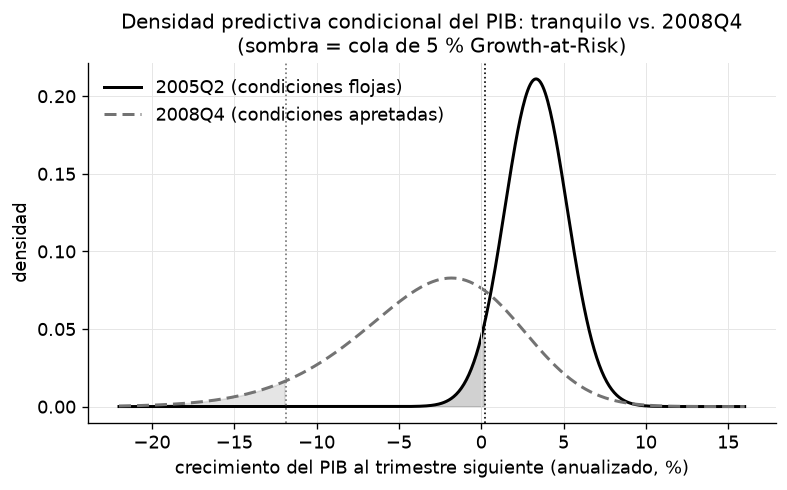

```python
cols = _nbstyle.palette(2)
xg = np.linspace(-22, 16, 500)
fig, ax = plt.subplots(figsize=(7.4, 3.9))
for (lab, F, c, ls) in (("2005Q2 (condiciones flojas)", F_calm, cols[0], "-"),
                        ("2008Q4 (condiciones apretadas)", F_tight, "0.45", (0, (4, 2)))):
    pdf = skewt_pdf(xg, F.mu, F.sigma, F.alpha, F.nu)
    ax.plot(xg, pdf, color=c, lw=1.8, ls=ls, label=lab)
    gar = F.ppf(0.05)
    ax.axvline(gar, color=c, lw=1.0, ls=":")
    ax.fill_between(xg, 0, pdf, where=(xg <= gar), color=c, alpha=0.18)
ax.axvline(0, color="0.85", lw=0.6)
ax.set_xlabel("crecimiento del PIB al trimestre siguiente (anualizado, %)")
ax.set_ylabel("densidad")
ax.set_title("Densidad predictiva condicional del PIB: tranquilo vs. 2008Q4\n"
             "(sombra = cola de 5 % Growth-at-Risk)")
ax.legend(loc="upper left")
plt.show()
```

### Figura 2 — El abanico de "vulnerable growth"

Aislamos el canal financiero: fijamos los rezagos en su media muestral y **barremos la NFCI**. Los cuantiles 5 %, 50 % y 95 % de $g_{t+1}$ dibujan un **abanico que se abre hacia abajo**. De un extremo al otro del barrido (NFCI de −0.9 a +3.2, los percentiles 2 y 99 de la muestra):

| cuantil | NFCI = −0.9 | NFCI = +3.2 | cambio |
| --- | --- | --- | --- |
| 5 % (GaR) | +1.2 % | −8.5 % | **−9.7 pp** |
| 50 % (mediana) | +3.4 % | +0.8 % | −2.5 pp |
| 95 % | +7.2 % | +8.0 % | +0.8 pp |

El 5 % se **hunde** casi diez puntos; la mediana cae **cuatro veces menos**; el 95 % prácticamente no se mueve. La asimetría de ABG (2019), en una imagen — y ojo: es la **mediana**, no la media, la que cae poco (con colas tan gruesas la media condicional no es un buen resumen).

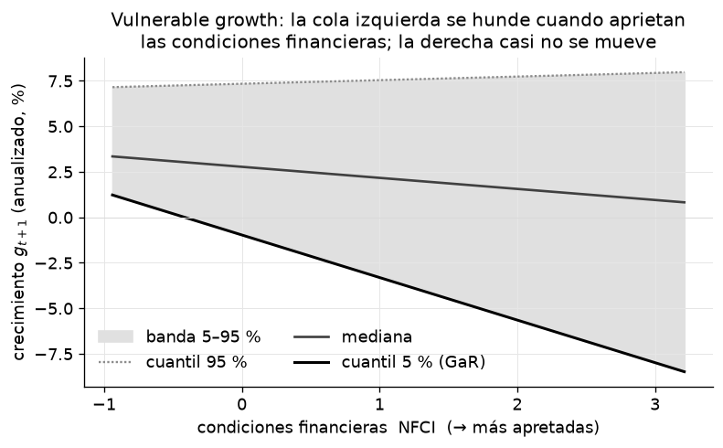

```python
lag_mean = panel["gdp"].mean()
nfci_grid = np.linspace(panel["nfci"].quantile(0.02), panel["nfci"].quantile(0.99), 40)
fan = {t: np.array([np.array([1.0, lag_mean, lag_mean, lag_mean, lag_mean, z])
                    @ Q.loc[t, betacols].values.astype(float) for z in nfci_grid])
       for t in (0.05, 0.50, 0.95)}

fig, ax = plt.subplots(figsize=(7.4, 3.9))
ax.fill_between(nfci_grid, fan[0.05], fan[0.95], color="0.88", label="banda 5–95 %")
ax.plot(nfci_grid, fan[0.95], color="0.55", lw=1.4, ls=(0, (1, 1)), label="cuantil 95 %")
ax.plot(nfci_grid, fan[0.50], color="0.25", lw=1.6, label="mediana")
ax.plot(nfci_grid, fan[0.05], color="0.00", lw=1.8, label="cuantil 5 % (GaR)")
ax.axhline(0, color="0.85", lw=0.6)
ax.set_xlabel("condiciones financieras  NFCI  (→ más apretadas)")
ax.set_ylabel("crecimiento $g_{t+1}$ (anualizado, %)")
ax.set_title("Vulnerable growth: la cola izquierda se hunde cuando aprietan\n"
             "las condiciones financieras; la derecha casi no se mueve")
ax.legend(loc="lower left", ncol=2)
plt.show()
```

### 2.4 Proyecciones locales cuantílicas (`lp_quantile`) y tablas de publicación

La autorregresión cuantílica (`qar`) asume una estructura dinámica paramétrica fija ($p=4$ rezagos comunes). Una vía alternativa y semi-paramétrica son las **proyecciones locales cuantílicas** (`puremacro.lp.lp_quantile`), que proyectan directamente el cuantil $\tau$ de $y_{t+h}$ sobre el choque o control financiero $x_t$, permitiendo que la dinámica de transmisión sea flexible horizonte por horizonte.

Comparamos la sensibilidad del crecimiento condicional a la NFCI en los cuantiles $\tau \in \{0.05, 0.50, 0.95\}$ a horizontes $h \in \{1, 2, 4\}$ (1 trimestre a 1 año adelante) y exportamos los resultados en formato de publicación con `puremacro.reports`.

```python
from puremacro.lp import lp_quantile
from puremacro.reports import df_to_markdown, df_to_latex

panel_lp = panel.reset_index()
res_lpq = lp_quantile(panel_lp, y="gdp", x="nfci", quantiles=(0.05, 0.50, 0.95),
                      horizons=(1, 2, 4), n_lags=4, n_boot=50, seed=1)

lpq_tab = []
for h_idx in (1, 2, 4):
    sub = res_lpq[res_lpq["h"] == h_idx].set_index("tau")
    lpq_tab.append({
        "h (trimestres)": h_idx,
        "GaR 5% (beta)": sub.loc[0.05, "beta"],
        "Mediana 50% (beta)": sub.loc[0.50, "beta"],
        "Cola der. 95% (beta)": sub.loc[0.95, "beta"],
    })
df_lpq_pub = pd.DataFrame(lpq_tab)

print("\n--- Sensibilidad del PIB a la NFCI por cuantiles y horizontes (Quantile LP) ---")
print(df_to_markdown(df_lpq_pub, digits=3))

assert res_lpq.shape[0] > 0
assert sub.loc[0.05, "beta"] < sub.loc[0.95, "beta"]  # a 1 año (h=4), la cola izquierda sigue cayendo más
```

[output not shown]

## 3. La humildad del dato en tiempo real (Orphanides)

Toda esa evaluación de riesgo se hace **en tiempo real, con el dato de hoy** — y el dato de hoy es **provisional**. Orphanides (2001) mostró que reglas y diagnósticos calculados con datos revisados **no son los que se pudieron calcular en el momento**. El caso emblemático es 2008Q4: leemos las **primeras publicaciones** del BEA y las comparamos con el valor **actual** (vintage revisado que cargamos arriba).

```python
vint = pd.read_csv(DATA / "alfred_pib_primeras_publicaciones.csv",
                   parse_dates=["release_date"])
v08 = vint[vint["quarter"] == "2008Q4"].sort_values("release_date")
actual_08 = float(g.loc["2008-10-01"])       # vintage actual, del mismo archivo del PIB

print("2008Q4 — cómo se vio el PIB con el paso del tiempo:")
for _, r in v08.iterrows():
    print(f"  {r['release_date']:%Y-%m-%d}  ({r['vintage']:>7}):  {r['growth_annualized']:+.1f}%")
print(f"  vintage actual (revisado):        {actual_08:+.1f}%")
primera = float(v08.iloc[0]["growth_annualized"])
print(f"\nEn tiempo real se vio {primera:+.1f}%; hoy sabemos que fue {actual_08:+.1f}% "
      f"— más del doble de profundo.")
```

```
2008Q4 — cómo se vio el PIB con el paso del tiempo:
  2009-01-30  (advance):  -3.8%
  2009-02-27  ( second):  -6.2%
  2009-03-26  (  third):  -6.3%
  vintage actual (revisado):        -8.5%

En tiempo real se vio -3.8%; hoy sabemos que fue -8.5% — más del doble de profundo.
```

### Las dos humildades se juntan: el GaR con el dato de enero de 2009

El predictor de 2008Q4 que usamos en §2 lleva dentro $g_t=-8.5$ — un número que **nadie tenía** cuando había que decidir. Rehagamos el mismo GaR sustituyendo ese rezago por el dato **de tiempo real** (−3.8 %) y dejando todo lo demás igual.

```python
for lab, g_t in (("con el dato revisado  (-8.5)", actual_08),
                 ("con el dato de enero 2009 (-3.8)", primera)):
    x = x_tight.copy(); x[1] = g_t
    F = fit_skewt_to_quantiles(cond_quantiles(x))
    print(f"{lab:>34}:  GaR 5% = {F.ppf(0.05):+6.1f}%   mediana = {F.ppf(0.50):+5.1f}%")
print("\nCon el dato disponible en el momento, el riesgo se veía ~1 punto menos negro y la\n"
      "mediana ~1.5 puntos mejor. La revisión del PIB no solo corrige la historia: corrige,\n"
      "hacia atrás, el riesgo que creíamos estar corriendo.")
```

```
      con el dato revisado  (-8.5):  GaR 5% =  -11.9%   mediana =  -2.6%
```

```
  con el dato de enero 2009 (-3.8):  GaR 5% =  -10.9%   mediana =  -1.1%

Con el dato disponible en el momento, el riesgo se veía ~1 punto menos negro y la
mediana ~1.5 puntos mejor. La revisión del PIB no solo corrige la historia: corrige,
hacia atrás, el riesgo que creíamos estar corriendo.
```

### Figura 3 — El mismo trimestre, distintas verdades

La caída de 2008Q4 se "profundizó" **sin que pasara nada nuevo**: solo llegaron las revisiones. Quien evaluó el riesgo en enero de 2009 lo hizo con **−3.8 %**, no con **−8.5 %**.

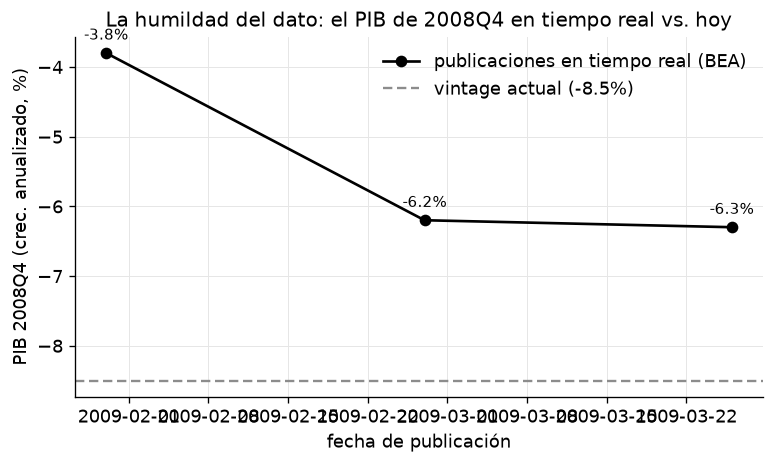

```python
fig, ax = plt.subplots(figsize=(7.4, 3.9))
ax.plot(v08["release_date"], v08["growth_annualized"], color="0.00",
        marker="o", lw=1.6, label="publicaciones en tiempo real (BEA)")
ax.axhline(actual_08, color="0.55", lw=1.4, ls=(0, (4, 2)),
           label=f"vintage actual ({actual_08:+.1f}%)")
for _, r in v08.iterrows():
    ax.annotate(f"{r['growth_annualized']:+.1f}%",
                (r["release_date"], r["growth_annualized"]),
                textcoords="offset points", xytext=(0, 8), fontsize=9, ha="center")
ax.set_ylabel("PIB 2008Q4 (crec. anualizado, %)")
ax.set_xlabel("fecha de publicación")
ax.set_title("La humildad del dato: el PIB de 2008Q4 en tiempo real vs. hoy")
ax.legend(loc="upper right")
plt.show()
```

## 4. Síntesis — por qué la media no basta

- El **agente representativo gaussiano** entrega una densidad simétrica y fija: el pronóstico puntual (la **media**) lo resume todo. No hay lugar para riesgo a la baja *asimétrico*.
- Los datos dicen otra cosa: al apretar las condiciones financieras, la **cola izquierda** del crecimiento se **engorda** (Figs. 1–2). Entre 2005Q2 y 2008Q4 el **5 % GaR** cae de ≈ +0.2 % a ≈ −11.9 %, mientras la mediana cae la mitad (de +3.3 % a −2.6 %); aislando el canal financiero (Fig. 2) la brecha es aún más nítida: −9.7 pp contra −2.5 pp. **La media pierde el riesgo.**
- Y encima, ese riesgo se evalúa **en tiempo real con el dato equivocado** (Fig. 3): la humildad del dato (Orphanides) se **suma** a la humildad del modelo.

La macro que solo mira la media pierde, por partida doble, lo que de verdad importa: la **cola**, y la **incertidumbre sobre el propio dato**.

## 6. Explora con IA

Prueba esto con el tutor sin conexión (o cualquier asistente de IA):

- "En una frase, ¿por qué la distribución del crecimiento del PIB es asimétrica según Adrian, Boyarchenko y Giannone (2019)?"
- "¿Por qué el problema del dato en tiempo real (Orphanides) empeora la evaluación de riesgo a la baja?"

```python
print(tutor("En una frase, ¿por qué la cola izquierda del crecimiento del PIB "
            "se engorda cuando aprietan las condiciones financieras (ABG 2019)?"))
```

[output not shown]

**Resumen.** Estimamos **Growth-at-Risk** con `puremacro.gar` —autorregresión cuantílica (`qar`) del PIB de EE. UU. con condiciones financieras, **1971Q1–2019Q4**, y una **skew-t** ajustada a los cuantiles (`fit_skewt_to_quantiles`, `skewt_pdf`)— y vimos que la **cola izquierda engorda** al apretar las condiciones (5 % GaR de +0.2 % a −11.9 % entre 2005Q2 y 2008Q4; Adrian, Boyarchenko y Giannone, 2019): el hecho que el agente representativo gaussiano, centrado en la **media**, no explica. Y añadimos la **humildad del dato en tiempo real** (Orphanides, 2001): el PIB de 2008Q4 se vio −3.8 % y hoy es −8.5 %. La macro que solo mira la media pierde el **riesgo a la baja**.

**Referencias.** Adrian, T., Boyarchenko, N. y Giannone, D. (2019), "Vulnerable Growth", *American Economic Review* 109(4), 1263–1289. · Orphanides, A. (2001), "Monetary Policy Rules Based on Real-Time Data", *American Economic Review* 91(4), 964–985.